# Credit Card Fraud Detection

Credit Card Fraud Detection Code

This Python script is designed for credit card fraud detection using a machine learning approach, particularly with a Random Forest Classifier.

The script performs the following steps:

- Load and Explore Data: Load the dataset using Pandas.Display a preview of the dataset, its shape, and basic statistics. Determine the number of fraud and valid transactions.
- Data Visualization:Visualize the correlation matrix using a heatmap to understand feature relationships.
- Data Preprocessing:Split the dataset into features (X) and the target variable (Y).Split the data into training and testing sets.
- Random Forest Classifier: Build a Random Forest Classifier model.Train the model on the training set.Make predictions on the test set.
- KNN: Build a KNN model.Train the model on the training set.Make predictions on the test set.
- Logistic Regression: Build a Logistic Regression model.Train the model on the training set.Make predictions on the test set.
- Decision Tree: Build a Decision Tree model.Train the model on the training set.Make predictions on the test set.
- Model Evaluation:Evaluate the model using various metrics such as accuracy, precision, recall, F1-score, and Matthews correlation coefficient. Display a confusion matrix to visualize the classifier's performance.

# Import libraries

```python
import numpy as np
import pandas as pd
from matplotlib import gridspec
```

# Read dataset

```python
df=pd.read_csv(r"C:\Users\Aishwarya\Downloads\creditcard.csv\creditcard.csv")
```

```python
df.head()
```

|  | Time | V1 | V2 | V3 | V4 | V5 | V6 | V7 | V8 | V9 | ... | V21 | V22 | V23 | V24 | V25 | V26 | V27 | V28 | Amount | Class |
| --- | --- | --- | --- | --- | --- | --- | --- | --- | --- | --- | --- | --- | --- | --- | --- | --- | --- | --- | --- | --- | --- |
| 0 | 0.0 | -1.359807 | -0.072781 | 2.536347 | 1.378155 | -0.338321 | 0.462388 | 0.239599 | 0.098698 | 0.363787 | ... | -0.018307 | 0.277838 | -0.110474 | 0.066928 | 0.128539 | -0.189115 | 0.133558 | -0.021053 | 149.62 | 0 |
| 1 | 0.0 | 1.191857 | 0.266151 | 0.166480 | 0.448154 | 0.060018 | -0.082361 | -0.078803 | 0.085102 | -0.255425 | ... | -0.225775 | -0.638672 | 0.101288 | -0.339846 | 0.167170 | 0.125895 | -0.008983 | 0.014724 | 2.69 | 0 |
| 2 | 1.0 | -1.358354 | -1.340163 | 1.773209 | 0.379780 | -0.503198 | 1.800499 | 0.791461 | 0.247676 | -1.514654 | ... | 0.247998 | 0.771679 | 0.909412 | -0.689281 | -0.327642 | -0.139097 | -0.055353 | -0.059752 | 378.66 | 0 |
| 3 | 1.0 | -0.966272 | -0.185226 | 1.792993 | -0.863291 | -0.010309 | 1.247203 | 0.237609 | 0.377436 | -1.387024 | ... | -0.108300 | 0.005274 | -0.190321 | -1.175575 | 0.647376 | -0.221929 | 0.062723 | 0.061458 | 123.50 | 0 |
| 4 | 2.0 | -1.158233 | 0.877737 | 1.548718 | 0.403034 | -0.407193 | 0.095921 | 0.592941 | -0.270533 | 0.817739 | ... | -0.009431 | 0.798278 | -0.137458 | 0.141267 | -0.206010 | 0.502292 | 0.219422 | 0.215153 | 69.99 | 0 |

5 rows × 31 columns

```python
df.info()
```

```
<class 'pandas.core.frame.DataFrame'>
RangeIndex: 284807 entries, 0 to 284806
Data columns (total 31 columns):
 #   Column  Non-Null Count   Dtype
---  ------  --------------   -----
 0   Time    284807 non-null  float64
 1   V1      284807 non-null  float64
 2   V2      284807 non-null  float64
 3   V3      284807 non-null  float64
 4   V4      284807 non-null  float64
 5   V5      284807 non-null  float64
 6   V6      284807 non-null  float64
 7   V7      284807 non-null  float64
 8   V8      284807 non-null  float64
 9   V9      284807 non-null  float64
```

[output cut: 23 more lines]

```python
df.isnull().sum()
```

```
Time      0
V1        0
V2        0
V3        0
V4        0
V5        0
V6        0
V7        0
V8        0
V9        0
V10       0
V11       0
V12       0
V13       0
V14       0
V15       0
V16       0
V17       0
V18       0
V19       0
V20       0
V21       0
V22       0
V23       0
V24       0
V25       0
V26       0
V27       0
V28       0
Amount    0
Class     0
dtype: int64
```

```python
df.isna().sum()
```

```
Time      0
V1        0
V2        0
V3        0
V4        0
V5        0
V6        0
V7        0
V8        0
V9        0
V10       0
V11       0
V12       0
V13       0
V14       0
V15       0
V16       0
V17       0
V18       0
V19       0
V20       0
V21       0
V22       0
V23       0
V24       0
V25       0
V26       0
V27       0
V28       0
Amount    0
Class     0
dtype: int64
```

# Data Visualization

```python
# Display the first few rows of the dataset
print("Preview of the dataset:")
print(df.head())
```

```
Preview of the dataset:
   Time        V1        V2        V3        V4        V5        V6        V7  \
0   0.0 -1.359807 -0.072781  2.536347  1.378155 -0.338321  0.462388  0.239599
1   0.0  1.191857  0.266151  0.166480  0.448154  0.060018 -0.082361 -0.078803
2   1.0 -1.358354 -1.340163  1.773209  0.379780 -0.503198  1.800499  0.791461
3   1.0 -0.966272 -0.185226  1.792993 -0.863291 -0.010309  1.247203  0.237609
4   2.0 -1.158233  0.877737  1.548718  0.403034 -0.407193  0.095921  0.592941

         V8        V9  ...       V21       V22       V23       V24       V25  \
0  0.098698  0.363787  ... -0.018307  0.277838 -0.110474  0.066928  0.128539
1  0.085102 -0.255425  ... -0.225775 -0.638672  0.101288 -0.339846  0.167170
2  0.247676 -1.514654  ...  0.247998  0.771679  0.909412 -0.689281 -0.327642
3  0.377436 -1.387024  ... -0.108300  0.005274 -0.190321 -1.175575  0.647376
4 -0.270533  0.817739  ... -0.009431  0.798278 -0.137458  0.141267 -0.206010

        V26       V27       V28  Amount  Class
0 -0.189115  0.133558 -0.021053  149.62      0
1  0.125895 -0.008983  0.014724    2.69      0
2 -0.139097 -0.055353 -0.059752  378.66      0
3 -0.221929  0.062723  0.061458  123.50      0
4  0.502292  0.219422  0.215153   69.99      0

[5 rows x 31 columns]
```

```python
df.shape
```

```
(284807, 31)
```

# EDA

```python
# Import libraries for EDA
import matplotlib.pyplot as plt
import seaborn as sns
```

```python
# Determine the number of fraud cases in the dataset
fraud = df[df['Class'] == 1]
valid = df[df['Class'] == 0]
outlier_fraction = len(fraud) / float(len(valid))
print("\nFraud Cases: {}".format(len(fraud)))
print("Valid Transactions: {}".format(len(valid)))
print("Outlier Fraction: {:.4f}".format(outlier_fraction))
```

```
Fraud Cases: 492
Valid Transactions: 284315
Outlier Fraction: 0.0017
```

```python
# Display amount details of fraudulent transactions
print("\nAmount details of the fraudulent transactions:")
print(fraud.Amount.describe())
```

```
Amount details of the fraudulent transactions:
count     492.000000
mean      122.211321
std       256.683288
min         0.000000
25%         1.000000
50%         9.250000
75%       105.890000
max      2125.870000
Name: Amount, dtype: float64
```

```python
# Display amount details of valid transactions
print("\nDetails of valid transactions:")
print(valid.Amount.describe())
```

```
Details of valid transactions:
count    284315.000000
mean         88.291022
std         250.105092
min           0.000000
25%           5.650000
50%          22.000000
75%          77.050000
max       25691.160000
Name: Amount, dtype: float64
```

```python
# Set the style for seaborn
sns.set(style="whitegrid")
```

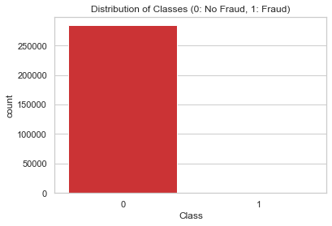

```python
# Plot distribution of the target variable (Class)
plt.figure(figsize=(6, 4))
sns.countplot(x='Class', data=df, palette='Set1')
plt.title('Distribution of Classes (0: No Fraud, 1: Fraud)')
plt.show()
```

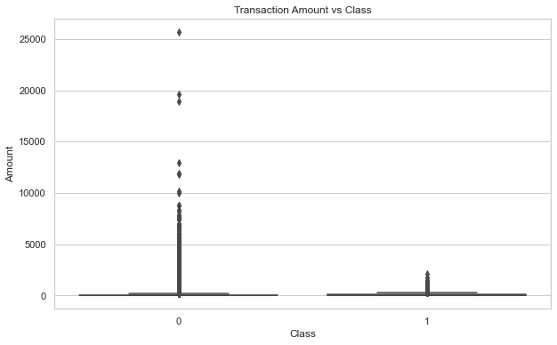

```python
# Plot distribution of transaction amounts for fraud and valid transactions
plt.figure(figsize=(10, 6))
sns.boxplot(x='Class', y='Amount', data=df, palette='Set1')
plt.title('Transaction Amount vs Class')
plt.show()
```

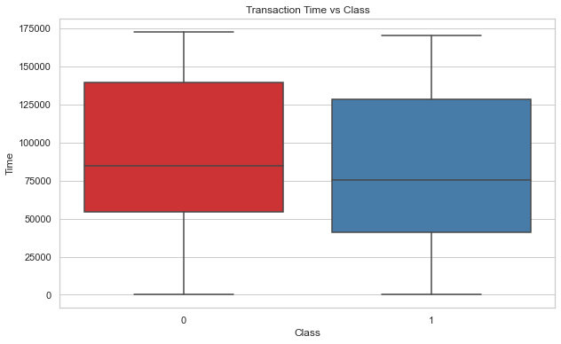

```python
# Plot distribution of transaction time for fraud and valid transactions
plt.figure(figsize=(10, 6))
sns.boxplot(x='Class', y='Time', data=df, palette='Set1')
plt.title('Transaction Time vs Class')
plt.show()
```

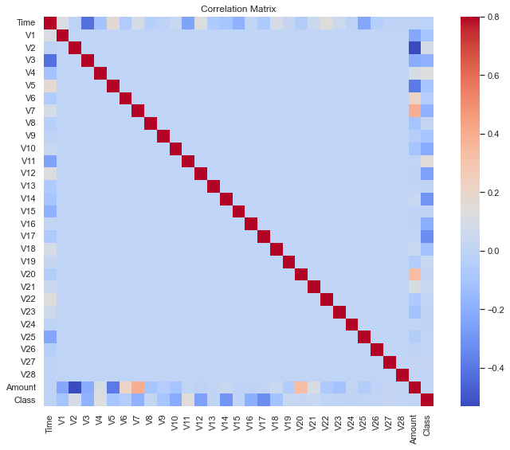

```python
# Plot correlation matrix
plt.figure(figsize=(12, 9))
sns.heatmap(corr_matrix, vmax=0.8, square=True, cmap='coolwarm')
plt.title("Correlation Matrix")
plt.show()
```

# Data Preprocessing X and Y

```python
# Divide the data into features (X) and target variable (Y)
X = df.drop(['Class'], axis=1)
Y = df["Class"]
```

```python
# Split the data into training and testing setsz
from sklearn.model_selection import train_test_split
x_train, x_test, y_train, y_test = train_test_split(X, Y, test_size=0.2, random_state=42)
```

# Random Forest

```python
# Build and train the Random Forest Classifier

from sklearn.ensemble import RandomForestClassifier
rf_classifier = RandomForestClassifier()
rf_classifier.fit(x_train, y_train)
```

```
RandomForestClassifier()
```

```python
# Make predictions on the test set
y_pred = rf_classifier.predict(x_test)
```

# Model Evaluation

```python
# Evaluate the classifier
print("\nModel Evaluation:")
print("The model used is Random Forest Classifier")
```

```
Model Evaluation:
The model used is Random Forest Classifier
```

```python
# Evaluate the classifier
from sklearn.metrics import classification_report, accuracy_score, precision_score, recall_score, f1_score, matthews_corrcoef, confusion_matrix
print("\nModel Evaluation:")
print("The model used is Random Forest Classifier")

accuracy = accuracy_score(y_test, y_pred)
precision = precision_score(y_test, y_pred)
recall = recall_score(y_test, y_pred)
f1 = f1_score(y_test, y_pred)
mcc = matthews_corrcoef(y_test, y_pred)
```

```
Model Evaluation:
The model used is Random Forest Classifier
```

```python
# Evaluate the classifier

from sklearn.metrics import classification_report, accuracy_score, precision_score, recall_score, f1_score, matthews_corrcoef, confusion_matrix
print("\nModel Evaluation:")
print("The model used is Random Forest Classifier")

accuracy = accuracy_score(y_test, y_pred)
precision = precision_score(y_test, y_pred)
recall = recall_score(y_test, y_pred)
f1 = f1_score(y_test, y_pred)
mcc = matthews_corrcoef(y_test, y_pred)

print("Accuracy: {:.4f}".format(accuracy))
print("Precision: {:.4f}".format(precision))
print("Recall: {:.4f}".format(recall))
print("F1-Score: {:.4f}".format(f1))
print("Matthews Correlation Coefficient: {:.4f}".format(mcc))
```

```
Model Evaluation:
The model used is Random Forest Classifier
Accuracy: 0.9996
Precision: 0.9744
Recall: 0.7755
F1-Score: 0.8636
Matthews Correlation Coefficient: 0.8691
```

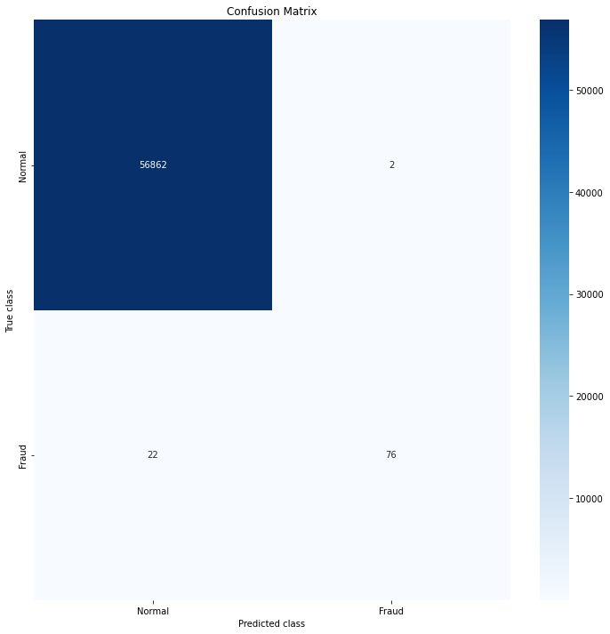

```python
# Display the confusion matrix with differentiated colors
labels = ['Normal', 'Fraud']
conf_matrix = confusion_matrix(y_test, y_pred)

plt.figure(figsize=(12, 12))
sns.heatmap(conf_matrix, xticklabels=labels, yticklabels=labels, annot=True, fmt="d", cmap="Blues")  # You can change "Blues" to another colormap
plt.title("Confusion Matrix")
plt.ylabel('True class')
plt.xlabel('Predicted class')
plt.show()
```

# KNN

```python
from sklearn.neighbors import KNeighborsClassifier
knn_model = KNeighborsClassifier()
knn_model.fit(x_train, y_train)

knn_predictions = knn_model.predict(x_test)
print("KNN Accuracy:", accuracy_score(y_test, knn_predictions))
print(classification_report(y_test, knn_predictions))
```

```
KNN Accuracy: 0.9983673326077034
              precision    recall  f1-score   support

           0       1.00      1.00      1.00     56864
           1       1.00      0.05      0.10        98

    accuracy                           1.00     56962
   macro avg       1.00      0.53      0.55     56962
weighted avg       1.00      1.00      1.00     56962
```

# Decision Tree

```python
from sklearn.tree import DecisionTreeClassifier
dt_model = DecisionTreeClassifier()
dt_model.fit(x_train, y_train)

dt_predictions = dt_model.predict(x_test)
print("Decision Tree Accuracy:", accuracy_score(y_test, dt_predictions))
print(classification_report(y_test, dt_predictions))
```

```
Decision Tree Accuracy: 0.9991397773954567
              precision    recall  f1-score   support

           0       1.00      1.00      1.00     56864
           1       0.72      0.83      0.77        98

    accuracy                           1.00     56962
   macro avg       0.86      0.91      0.88     56962
weighted avg       1.00      1.00      1.00     56962
```

# Logistic Regression

```python
from warnings import filterwarnings
filterwarnings("ignore")

from sklearn.linear_model import LogisticRegression
logreg_model = LogisticRegression()
logreg_model.fit(x_train, y_train)

logreg_predictions = logreg_model.predict(x_test)
print("logistic regression Accuracy:", accuracy_score(y_test, logreg_predictions))
print(classification_report(y_test, logreg_predictions))
```

```
logistic regression Accuracy: 0.9987008883115059
              precision    recall  f1-score   support

           0       1.00      1.00      1.00     56864
           1       0.65      0.52      0.58        98

    accuracy                           1.00     56962
   macro avg       0.83      0.76      0.79     56962
weighted avg       1.00      1.00      1.00     56962
```